# Description

This track hub is a part of the paper "An extended catalogue of tandem alternative splice sites in human tissue transcriptomes" by Mironov et al.

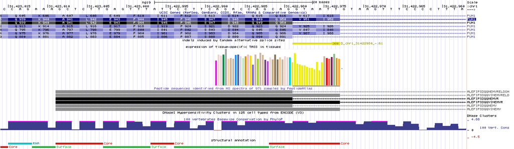

The hub consists of three tracks:

1) TASS indels. The regions between each pair of major splice site (maSS) and minor splice site (miSS) are shown. The position of the maSS is denoted with the thick track width. Colors denote the expression category of miSS: non-significantly expressed (grey), significant but non-tissue-specific (orange), tissue-specific (yellow)

2) Tissue-specific TASS. The barplots demonstrating the expression of tissue-specific miSS in tissues are shown. The expression is measured by $\varphi$ value. Note that the UCSC genome browser automatically performs $Log_{10}(x+1)$ transformation for this type of track. One can turn it off in the settings of the track.

3) Structural annotation. The structural annotation of the human proteome was produced with StructMAn (A. Gress et al., 2016) and mapped onto the human transcriptome. The following structural categories are presented:

- protein core (Core, red),
- protein-protein interaction sites (PPI, blue),
- ligand-binding sites (Ligand, olive),
- metal-binding sites (Metal, magenta),
- RNA-binding sites (RNA, cyan),
- DNA-binding sites (DNA, orange),
- protein surface regions (Surface, green),
- disordered regions (Disorder, grey).